# Investigating Hotel Booking Demand

## Preliminary Wrangling

> This dataset was downloaded from Kaggle and is available through this link https://www.kaggle.com/jessemostipak/hotel-booking-demand. It is originally from an article by Nuno Antonio, Ana Almeida, and Luis Nunes for Data in Brief, Volume 22, February 2019.

> This data set contains booking information for a city hotel and a resort hotel made worldwide, and includes information such as when the booking was made, duration of stay, the number of adults, children, and/or babies, and the number of available parking spaces, among other things from 2015 to 2017.

```python
# import all packages and set plots to be embedded inline
import numpy as np
import pandas as pd
import matplotlib.pyplot as plt
import seaborn as sb

%matplotlib inline
```

### Importing data

```python
df = pd.read_csv('hotel_bookings.csv')
```

```python
df.shape
```

```
(119390, 32)
```

```python
df.head()
```

|  | hotel | is_canceled | lead_time | arrival_date_year | arrival_date_month | arrival_date_week_number | arrival_date_day_of_month | stays_in_weekend_nights | stays_in_week_nights | adults | ... | deposit_type | agent | company | days_in_waiting_list | customer_type | adr | required_car_parking_spaces | total_of_special_requests | reservation_status | reservation_status_date |
| --- | --- | --- | --- | --- | --- | --- | --- | --- | --- | --- | --- | --- | --- | --- | --- | --- | --- | --- | --- | --- | --- |
| 0 | Resort Hotel | 0 | 342 | 2015 | July | 27 | 1 | 0 | 0 | 2 | ... | No Deposit | NaN | NaN | 0 | Transient | 0.0 | 0 | 0 | Check-Out | 2015-07-01 |
| 1 | Resort Hotel | 0 | 737 | 2015 | July | 27 | 1 | 0 | 0 | 2 | ... | No Deposit | NaN | NaN | 0 | Transient | 0.0 | 0 | 0 | Check-Out | 2015-07-01 |
| 2 | Resort Hotel | 0 | 7 | 2015 | July | 27 | 1 | 0 | 1 | 1 | ... | No Deposit | NaN | NaN | 0 | Transient | 75.0 | 0 | 0 | Check-Out | 2015-07-02 |
| 3 | Resort Hotel | 0 | 13 | 2015 | July | 27 | 1 | 0 | 1 | 1 | ... | No Deposit | 304.0 | NaN | 0 | Transient | 75.0 | 0 | 0 | Check-Out | 2015-07-02 |
| 4 | Resort Hotel | 0 | 14 | 2015 | July | 27 | 1 | 0 | 2 | 2 | ... | No Deposit | 240.0 | NaN | 0 | Transient | 98.0 | 0 | 1 | Check-Out | 2015-07-03 |

5 rows × 32 columns

```python
df.describe()
```

|  | is_canceled | lead_time | arrival_date_year | arrival_date_week_number | arrival_date_day_of_month | stays_in_weekend_nights | stays_in_week_nights | adults | children | babies | is_repeated_guest | previous_cancellations | previous_bookings_not_canceled | booking_changes | agent | company | days_in_waiting_list | adr | required_car_parking_spaces | total_of_special_requests |
| --- | --- | --- | --- | --- | --- | --- | --- | --- | --- | --- | --- | --- | --- | --- | --- | --- | --- | --- | --- | --- |
| count | 119390.000000 | 119390.000000 | 119390.000000 | 119390.000000 | 119390.000000 | 119390.000000 | 119390.000000 | 119390.000000 | 119386.000000 | 119390.000000 | 119390.000000 | 119390.000000 | 119390.000000 | 119390.000000 | 103050.000000 | 6797.000000 | 119390.000000 | 119390.000000 | 119390.000000 | 119390.000000 |
| mean | 0.370416 | 104.011416 | 2016.156554 | 27.165173 | 15.798241 | 0.927599 | 2.500302 | 1.856403 | 0.103890 | 0.007949 | 0.031912 | 0.087118 | 0.137097 | 0.221124 | 86.693382 | 189.266735 | 2.321149 | 101.831122 | 0.062518 | 0.571363 |
| std | 0.482918 | 106.863097 | 0.707476 | 13.605138 | 8.780829 | 0.998613 | 1.908286 | 0.579261 | 0.398561 | 0.097436 | 0.175767 | 0.844336 | 1.497437 | 0.652306 | 110.774548 | 131.655015 | 17.594721 | 50.535790 | 0.245291 | 0.792798 |
| min | 0.000000 | 0.000000 | 2015.000000 | 1.000000 | 1.000000 | 0.000000 | 0.000000 | 0.000000 | 0.000000 | 0.000000 | 0.000000 | 0.000000 | 0.000000 | 0.000000 | 1.000000 | 6.000000 | 0.000000 | -6.380000 | 0.000000 | 0.000000 |
| 25% | 0.000000 | 18.000000 | 2016.000000 | 16.000000 | 8.000000 | 0.000000 | 1.000000 | 2.000000 | 0.000000 | 0.000000 | 0.000000 | 0.000000 | 0.000000 | 0.000000 | 9.000000 | 62.000000 | 0.000000 | 69.290000 | 0.000000 | 0.000000 |
| 50% | 0.000000 | 69.000000 | 2016.000000 | 28.000000 | 16.000000 | 1.000000 | 2.000000 | 2.000000 | 0.000000 | 0.000000 | 0.000000 | 0.000000 | 0.000000 | 0.000000 | 14.000000 | 179.000000 | 0.000000 | 94.575000 | 0.000000 | 0.000000 |
| 75% | 1.000000 | 160.000000 | 2017.000000 | 38.000000 | 23.000000 | 2.000000 | 3.000000 | 2.000000 | 0.000000 | 0.000000 | 0.000000 | 0.000000 | 0.000000 | 0.000000 | 229.000000 | 270.000000 | 0.000000 | 126.000000 | 0.000000 | 1.000000 |
| max | 1.000000 | 737.000000 | 2017.000000 | 53.000000 | 31.000000 | 19.000000 | 50.000000 | 55.000000 | 10.000000 | 10.000000 | 1.000000 | 26.000000 | 72.000000 | 21.000000 | 535.000000 | 543.000000 | 391.000000 | 5400.000000 | 8.000000 | 5.000000 |

```python
df.info()
```

```
<class 'pandas.core.frame.DataFrame'>
RangeIndex: 119390 entries, 0 to 119389
Data columns (total 32 columns):
 #   Column                          Non-Null Count   Dtype
---  ------                          --------------   -----
 0   hotel                           119390 non-null  object
 1   is_canceled                     119390 non-null  int64
 2   lead_time                       119390 non-null  int64
 3   arrival_date_year               119390 non-null  int64
 4   arrival_date_month              119390 non-null  object
 5   arrival_date_week_number        119390 non-null  int64
 6   arrival_date_day_of_month       119390 non-null  int64
 7   stays_in_weekend_nights         119390 non-null  int64
 8   stays_in_week_nights            119390 non-null  int64
 9   adults                          119390 non-null  int64
```

[output cut: 24 more lines]

### Data Wrangling

```python
df.duplicated().sum()
```

```
31994
```

```python
df.isnull().sum()
```

```
hotel                                  0
is_canceled                            0
lead_time                              0
arrival_date_year                      0
arrival_date_month                     0
arrival_date_week_number               0
arrival_date_day_of_month              0
stays_in_weekend_nights                0
stays_in_week_nights                   0
adults                                 0
children                               4
babies                                 0
meal                                   0
country                              488
market_segment                         0
distribution_channel                   0
is_repeated_guest                      0
previous_cancellations                 0
previous_bookings_not_canceled         0
reserved_room_type                     0
assigned_room_type                     0
booking_changes                        0
deposit_type                           0
agent                              16340
company                           112593
days_in_waiting_list                   0
customer_type                          0
adr                                    0
required_car_parking_spaces            0
total_of_special_requests              0
reservation_status                     0
reservation_status_date                0
dtype: int64
```

```python
df.drop(['company','arrival_date_week_number'],axis=1,inplace=True)
```

- Replacing missing values in the agent and children variables with their median

```python
agent_median = df.agent.median()
df.agent.fillna(agent_median,inplace=True)
```

```python
children_median = df.children.median()
df.children.fillna(children_median,inplace=True)
```

- Replacing missing values in country variable with its mode

```python
country_mode = df.country.mode()
df.country.fillna(str(country_mode),inplace=True)
```

```python
df.isnull().sum().sum()
```

```
0
```

```python
df.sample(5)
```

|  | hotel | is_canceled | lead_time | arrival_date_year | arrival_date_month | arrival_date_day_of_month | stays_in_weekend_nights | stays_in_week_nights | adults | children | ... | deposit_type | agent | days_in_waiting_list | customer_type | adr | required_car_parking_spaces | total_of_special_requests | reservation_status | reservation_status_date | arrival_date |
| --- | --- | --- | --- | --- | --- | --- | --- | --- | --- | --- | --- | --- | --- | --- | --- | --- | --- | --- | --- | --- | --- |
| 28583 | Resort Hotel | 0 | 1 | 2016 | October | 5 | 0 | 1 | 3 | 0.0 | ... | No Deposit | 14.0 | 0 | Transient | 156.0 | 1 | 2 | Check-Out | 2016-10-06 | 5/October/2016 |
| 60198 | City Hotel | 1 | 277 | 2016 | November | 7 | 1 | 2 | 2 | 0.0 | ... | Non Refund | 14.0 | 0 | Transient | 100.0 | 0 | 0 | Canceled | 2016-04-04 | 7/November/2016 |
| 84762 | City Hotel | 0 | 5 | 2016 | March | 2 | 0 | 1 | 1 | 0.0 | ... | No Deposit | 14.0 | 0 | Transient | 66.0 | 0 | 0 | Check-Out | 2016-03-03 | 2/March/2016 |
| 47610 | City Hotel | 1 | 1 | 2016 | February | 28 | 2 | 1 | 1 | 0.0 | ... | No Deposit | 134.0 | 0 | Transient-Party | 60.0 | 0 | 0 | Canceled | 2016-02-27 | 28/February/2016 |
| 16937 | Resort Hotel | 0 | 13 | 2017 | January | 24 | 0 | 2 | 1 | 0.0 | ... | No Deposit | 14.0 | 0 | Transient | 35.0 | 0 | 0 | Check-Out | 2017-01-26 | 24/January/2017 |

5 rows × 31 columns

> The data has 119390 row observations and 30 columns which will be referred to as variables.

> Main features of the data are the arrival dates, including year and month, country in addition to previous booking made or if the guest is repeated

```python
# Defining a new function that takes on arguments to create a histogram
def histogram(column, title, binsize, xlabel):
    # make space
    plt.figure(figsize = (16,8))
    plt.subplot(1,2,1)
    binsize = np.arange(0, df[column].max()+binsize,binsize)
    plt.hist(data=df, x = column, bins = binsize)
    plt.title('Distribution of {}'.format(title))
    plt.xlabel(xlabel)

    plt.subplot(1,2,2)
    plt.hist(data=df, x = column, bins = binsize)
    plt.title('Log distribution of {}'.format(title))
    plt.xscale('log')
    plt.xticks([10,30,100,300,1000])
    plt.xlabel(xlabel)
```

## Univariate Exploration

**1. Which hotel type is preferred?**

```python
hotel_types = df.hotel.value_counts()
```

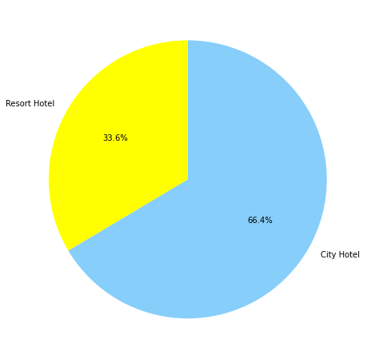

```python
plt.figure(figsize=(8,8))
coloring = ('lightskyblue','yellow')
plt.pie(hotel_types,labels=hotel_types.index,startangle=90,counterclock=False,autopct='%1.1f%%',colors=coloring);
```

`The pie chart shows that the majority of bookings made prefer city hotels to resort hotels`

**2. In what year were most bookings made?**

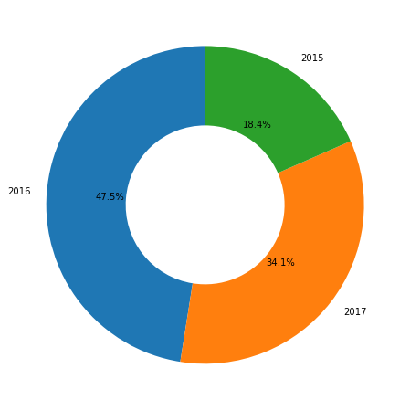

```python
years_count=df.arrival_date_year.value_counts()
plt.figure(figsize=(8,8))
plt.pie(years_count,labels=years_count.index,startangle=90,autopct='%1.1f%%',wedgeprops={'width':0.5});
```

`The donut chart displays the number of booking made throughout a 3 year period, starting from 2015 until 2017 and indicates that almost half of the bookings were made during 2016`

**3. What proportion of bookings were cancelled?**

```python
cancellation_counts = df.is_canceled.value_counts()
```

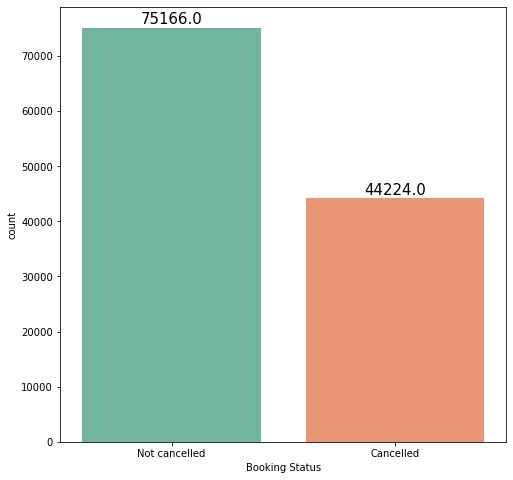

```python
plt.figure(figsize=(8,8))
g=sb.countplot(data=df,x='is_canceled',palette='Set2')
g.set_xticklabels(['Not cancelled','Cancelled'])
plt.xlabel('Booking Status');
for bar in g.patches:
  g.annotate(format(bar.get_height(), '.1f'),
                   (bar.get_x() + bar.get_width() / 2,
                    bar.get_height()), ha='center', va='center',
                   size=15, xytext=(0, 8),
                   textcoords='offset points')
```

`It is clear that the majority of bookings made are not cancelled (over 60%)`

**4. Which months are the busiest and how does seasonality affect hotel bookings?**

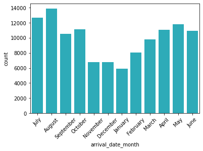

```python
basecolor = sb.color_palette()[9]
sb.countplot(data=df,x='arrival_date_month',color=basecolor)
plt.xticks(rotation=45);
```

`As expected and due to whether variations throughout the year during different seasons, it can be illustrate that hotel booking demand vary from each season to the other and that it peaks during the summer season (June, July and August) and is at its lowest during the winter season (November, December and January)`

**5. What is the distribution of lead time?**

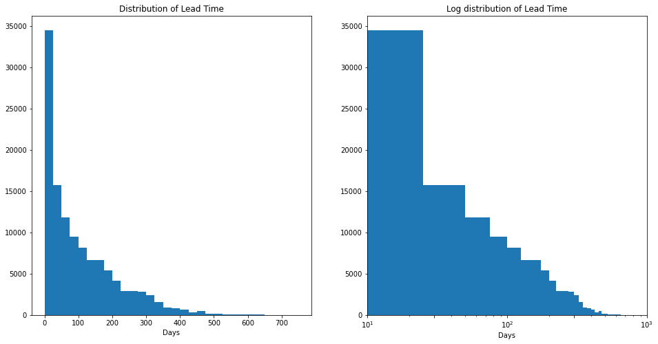

```python
histogram('lead_time','Lead Time',25,'Days')
```

`Lead time represents the number of days elapsed between the booking entering the system (PMS) and the time of arrival. Several observations could be made from the histogram plot and its corresponding log plot. Firstly, the distribution is skewed to the right depicting that most bookings have a lead time between 0 to 100. Another inference is that as lead time increases, number of bookings drops and hence most bookings are made within 0 to 100 days prior to arrival`

**6. What are the most and least popular destinations?**

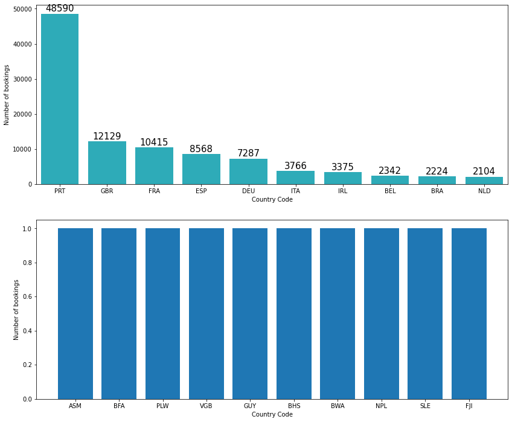

```python
popular_dest=df.country.value_counts()[0:10]
least_popular_dest = df.country.value_counts()[-11:-1]
plt.figure(figsize=(14,12))

plt.subplot(2,1,1)
g1=sb.barplot(popular_dest.index,popular_dest,color=basecolor)
plt.xlabel('Country Code')
plt.ylabel('Number of bookings')
for bar in g1.patches:
  g1.annotate(format(bar.get_height(), '.0f'),
                   (bar.get_x() + bar.get_width() / 2,
                    bar.get_height()), ha='center', va='center',
                   size=15, xytext=(0, 8),
                   textcoords='offset points')


plt.subplot(2,1,2)
plt.bar(least_popular_dest.index,least_popular_dest)
plt.xlabel('Country Code')
plt.ylabel('Number of bookings');
```

```
Upon comparison of the two bar charts depicting number of booking made in each country, it is evident that the most popular destination is country code PRT which stands for Portugal. This is followed by GBR (Great Britain), FRA (France) and ESP (Spain)
On the other hand, there seems to be several countries where only a single booking has been made
```

**7. What is the distribution of the Average Daily Rate?**

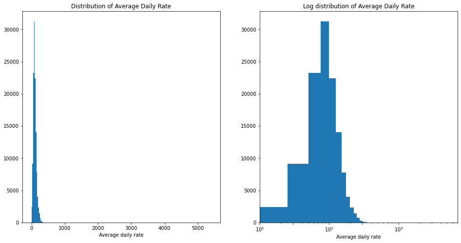

```python
histogram('adr','Average Daily Rate',25,'Average daily rate')
```

`The average daily rate variable, shortened to adr, is an engineered feature that is defined by dividing the sum of all lodging transactions by the total number of staying nights or simply the average price per night. The distribution of the average daily rate appears to be unimodal where the mean is approxiamtely 100`

**8. What is the typical payment policy set by hotels?**

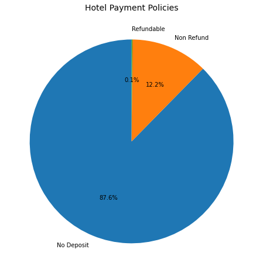

```python
payment_count=df.deposit_type.value_counts()
plt.figure(figsize=(8,8))
plt.pie(payment_count,labels=payment_count.index,startangle=90,autopct='%1.1f%%')
plt.title('Hotel Payment Policies',fontsize=14);
```

`The overwhelming majority of hotels require no deposit to be made in advance for each bookiing while only an extremely small proportion of hotels offer a refundable deposit`

**9. What is the distribution of the total nights stay-in duration?**

```python
df['total_night_stay_in'] = df['stays_in_weekend_nights'] + df['stays_in_week_nights']
```

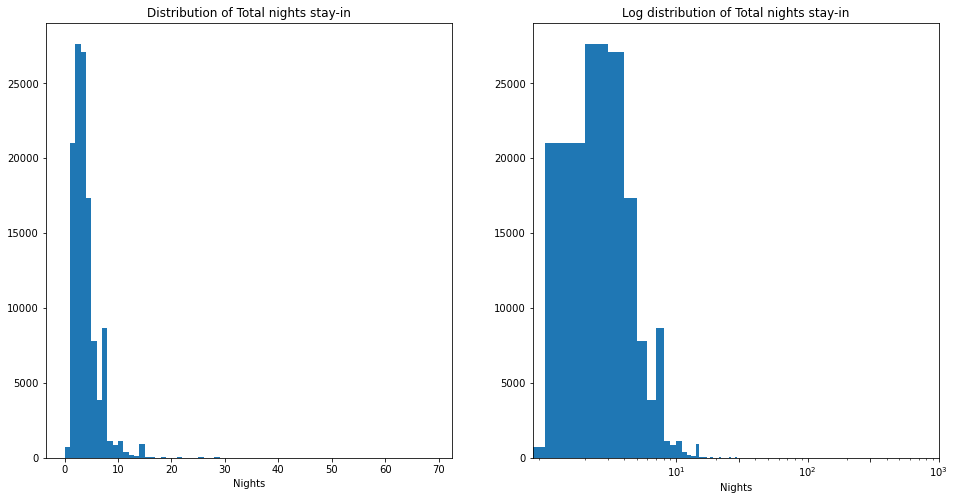

```python
histogram('total_night_stay_in','Total nights stay-in',1,'Nights')
```

**10. What kind of meal plans provided by the hotel are preferred?**

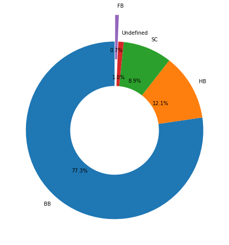

```python
meal_counts = df.meal.value_counts()
plt.figure(figsize=(8,8))
explode=(0,0,0,0,0.3)
plt.pie(meal_counts,labels=meal_counts.index,startangle=90,autopct='%1.1f%%',explode=explode,wedgeprops={'width':0.5});
```

`An overwhelming proportion of bookings made choose BB (Bed and Breakfast), while HB (Half Board) the second most chosen meal plans which is followed by SC and undefined that represent no meal being provided`

**11. What is the distribution of days in waiting list?**

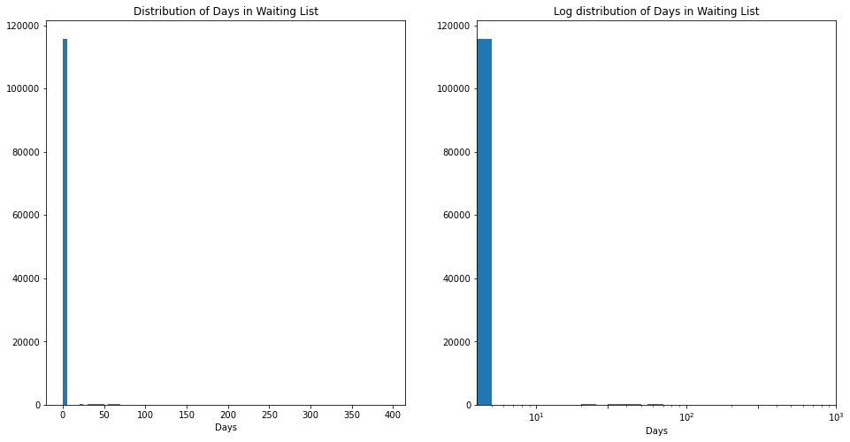

```python
histogram('days_in_waiting_list','Days in Waiting List',5,'Days')
```

`Distribution of days spent in waiting list outlines that almost all of the bookings wait for only a couple of days`

**12. What kind of distribution channel is the most common?**

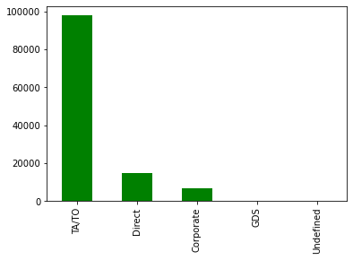

```python
df.distribution_channel.value_counts().plot(kind='bar',color='green');
```

`Note that TA stands for Travel Agents while TO means Tour Operators. Both TA and TO appear to be the most common distribution channel`

### Transformations

> Variables that consist of quantitative data were investigated graphically, most of which appeared to be skewed to the right. In some cases, the skewness in those variables were mainly attributed to the outliers. Log transformations were performed to conform the data into normality.

### Tidying operations

> Firstly, the company column was dropped since it had many missing values making it interpretable and hence was removed. Additionally, missing values in the agent and children variables were replaced with their median whereas the missing values in country were replaced with the mode which was found to be PRT (or Portugal)

## Bivariate Exploration

> In this section, relationships between pairs of variables will be investigated.

**1. Is there a relationship between the lead time and booking cancellations?**

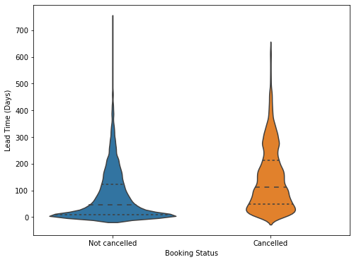

```python
plt.figure(figsize=(8,6))
g2=sb.violinplot(data=df,x='is_canceled',y='lead_time',inner='quartile')
g2.set_xticklabels(['Not cancelled','Cancelled'])
plt.xlabel('Booking Status')
plt.ylabel('Lead Time (Days)');
```

```
Violin plots demonstrate how the cancelled bookings median is higher than that of not cancelled bookings. This may be attributed to the fact that the number of not cancelled bookings is considerably larger than number of cancelled ones.
Another inference suggested by the violin plots is that most of cancelled bookings have a longer lead time indicating that the interval between the entrance of a booking into the system and its corresponding time of arrival is longer than that of not cancelled bookings
```

**2. What is the relationship between lead time and number of adults?**

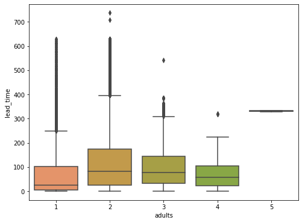

```python
plt.figure(figsize=(8,6))
sb.boxplot(data=df,x='adults',y='lead_time')
plt.xlim(0.5,5.5);
```

`It seems that the number of adults have no to little significance on lead time`

**3. Is there a relationship between the arrival months and average daily rate?**

```python
monthlist = ['July', 'August', 'September', 'October', 'November', 'December',
       'January', 'February', 'March', 'April', 'May', 'June']
```

```python
monthslist = pd.api.types.CategoricalDtype(ordered=True,categories=monthlist)
```

```python
df['arrival_date_month'] = df['arrival_date_month'].astype(monthslist)
```

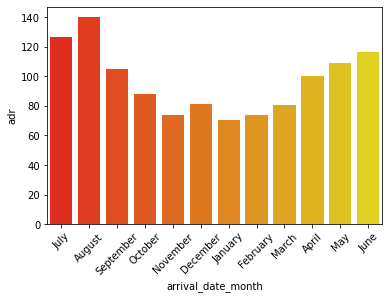

```python
sb.barplot(data=df,x='arrival_date_month',y='adr',palette='autumn',ci=False)
plt.xticks(rotation=45);
```

`It seems that the more in demand hotel booking are, the higher the average daily rate becomes and it can be seen that it follows the same trend as number of hotel bookings throughout the year`

**4. Is there a correlation between days spent in the waiting list and cancellations?**

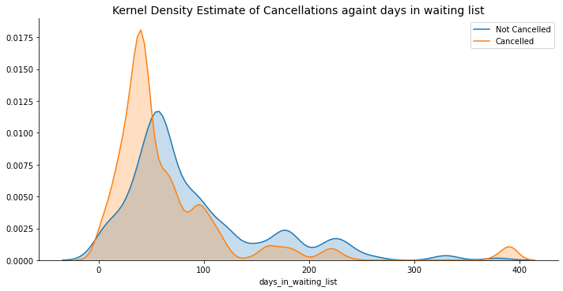

```python
sb.FacetGrid(df[df['days_in_waiting_list']>0],hue='is_canceled',height=5,aspect=2,).map(sb.kdeplot,'days_in_waiting_list',shade=True)
plt.title('Kernel Density Estimate of Cancellations againt days in waiting list',fontsize=14)
plt.legend(['Not Cancelled','Cancelled']);
```

**5. Does the payment policy influence booking cancellations?**

```python
deposit_cancellation = pd.concat([df.groupby('deposit_type').sum()['is_canceled'],
                                 df.deposit_type.value_counts()],axis=1)
```

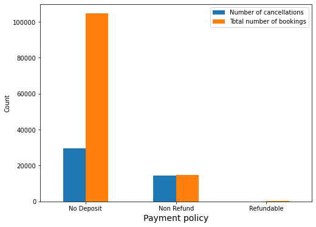

```python
deposit_cancellation.plot(kind='bar',figsize=(8,6))
plt.legend(['Number of cancellations','Total number of bookings'])
plt.xticks(rotation=0)
plt.xlabel('Payment policy',fontsize=14)
plt.ylabel('Count');
```

`Surprisingly, almost all of the bookings made at hotels that offer a non refund (payment equal to total cost of stay) were cancelled, whereas only a fraction of the bookings made at hotels that require no deposit where cancelled`

**6. Which type of hotel receives more cancellations?**

```python
hotel_cancellation = pd.concat([df.groupby('hotel').sum()['is_canceled'],df.hotel.value_counts()],axis=1)
```

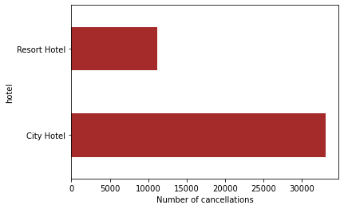

```python
hotel_cancellation.is_canceled.plot(kind='barh',color='brown')
plt.xlabel('Number of cancellations');
```

`The horizontal bar chart clearly shows that city hotel receive a larger number of cancellations compared to resort hotels which is natural given that there is more demand for city hotels`

**7. How does the average daily rate differ between hotel types?**

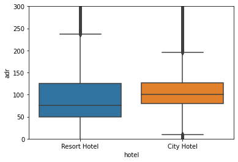

```python
sb.boxplot(data=df,x='hotel',y='adr')
plt.ylim(0,300);
```

`The average daily rate for city hotels cost, on average, more than resort hotels`

**8. Does the average daily rate increase when there are more adults?**

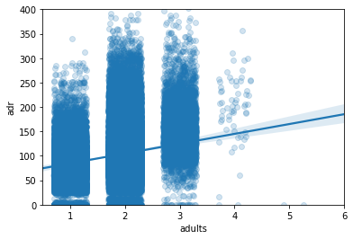

```python
sb.regplot(data=df,x='adults',y='adr',x_jitter=0.3,scatter_kws={'alpha':0.2})
plt.xlim(0.5,6)
plt.ylim(0,400);
```

`There is an upward trend between the two variables, which means that the average daily rate rises when there are more adults`

### A second relationship found was between the average daily rate and number of adults where there is a positive correlation between the two variables.

## Multivariate Exploration

**1. How does the average daily rate vary throughout the year?**

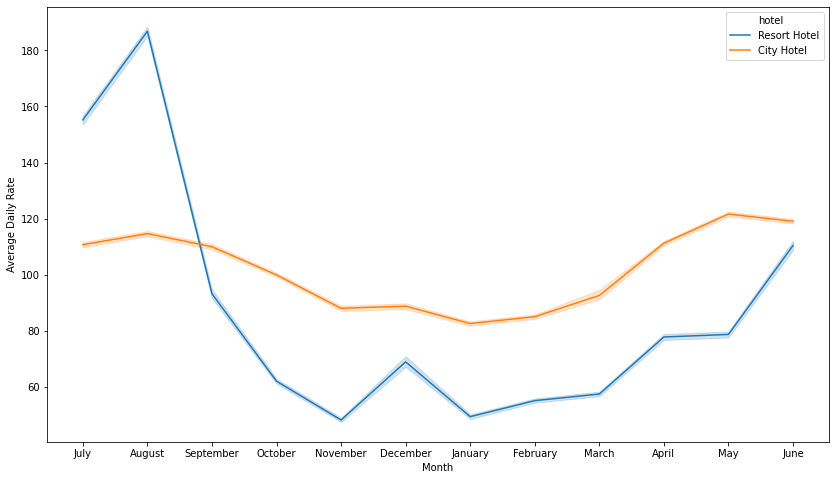

```python
plt.figure(figsize=(14,8))
sb.lineplot(data=df,x='arrival_date_month',y='adr',hue='hotel')
plt.xlabel('Month')
plt.ylabel('Average Daily Rate');
```

`A number of observations can be made by analyzing the time series plot, these are:`

- Resort hotels are more expensive than city hotels only during July and August
- Resort hotel average daily rate tends to fluctuate more than city hotels along the year
- Average daily rates are the lowest during winter season for all hotel types, with the exception being during December, which may be because of the holiday and festive season.

**2. Relationship between number of days spent in waiting list for each booking and the lead time by hotel type**

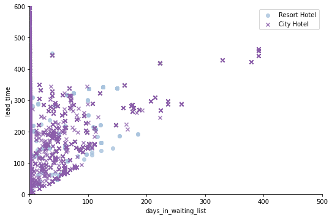

```python
#plt.figure(figsize=(10,10))
sb.lmplot(data=df,x='days_in_waiting_list',y='lead_time',hue='hotel',fit_reg=False,size=5,aspect=1.5,legend=False
         ,markers=['o','x'],palette='BuPu');
plt.ylim(0,600)
plt.xlim(0,500)
plt.legend();
```

`Lead time has a positive correlation with days in waiting list.`